# Part II - A Breakdown Of How Prosper Loans Work

## by Bhadmus Samiat

## Investigation Overview

> 1. Most of the borrowers are employed.
> 2. Borrowers are mostly from Califronia, Texas and Newyork.
> 3. The larger the loan a borrower collects, the higher the money the borrower will pay monthly.
> 4. Large loans leads to smaller APR.
> 5. Borrowers with high income range tends to collect large loans.

## Dataset Overview

> The prosper loan dataset contains 113,937 with 81 variables on each loan, including loan amount, borrower rate(or interest rate),current loan status, borrower income, and many others.

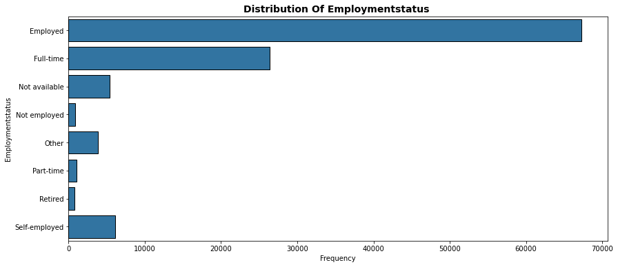

Interestingly, most of the people that borrows prosper loan are employed.

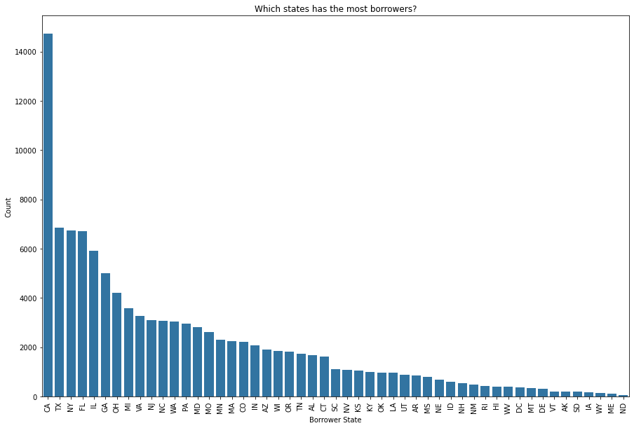

Califronia, Texas and Newyork are the top 3 states with the highest borrowers.

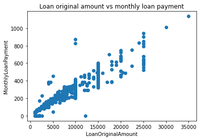

We can see that as the loan amount increases, the monthly loan payment that the borrowers pays increases which means that the higher a borrowers borrow a money, the higher the money he or she would pay monthly and vice versa.

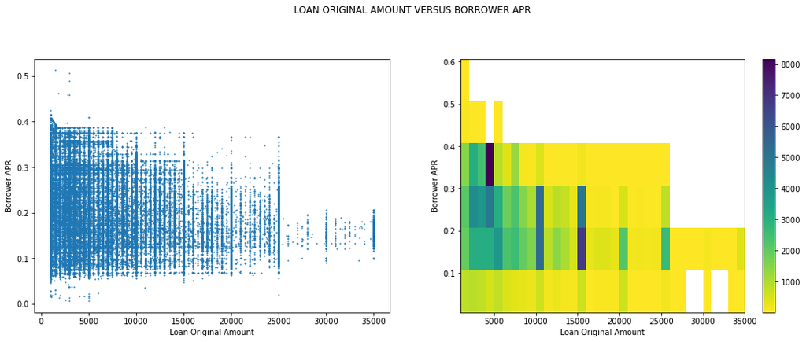

Although it is not that noticeable, loan original amount and borrower APR are negative correlated which means that as the loan original amount increases, the borrower APR decreases.

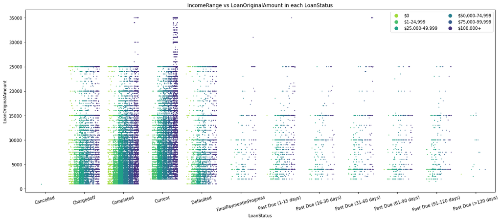

We can see that as the income range increases for most of the loan status, the original loan amount increases. This means that borrowers with high income range tends to borrow more loan than does with low income.